# Analítica de datos aplicada a estudios sobre desarrollo

Introducción a las técnicas multivariantes no supervisadas

[Giovany Babativa, PhD](http://jgbabativam.rbind.io/)

## Proceso de analítica

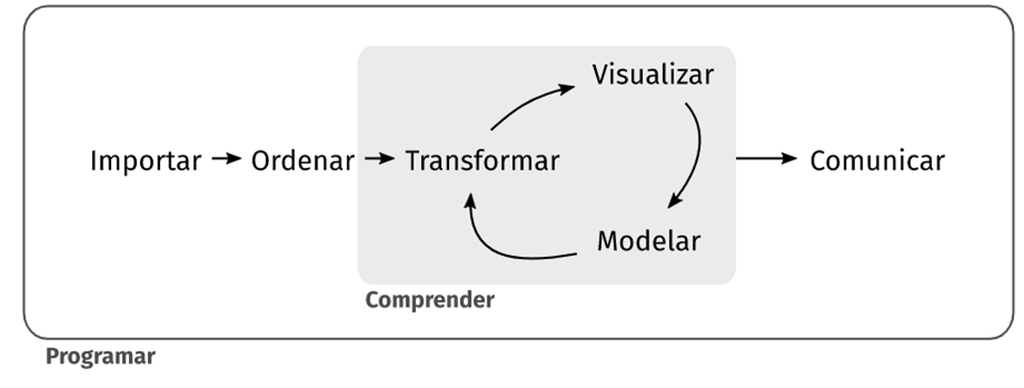

[Wickham, H. y otros (2023)](https://r4ds.hadley.nz/)

# MÉTODOS MULTIVARIANTES

## Modelos de analítica

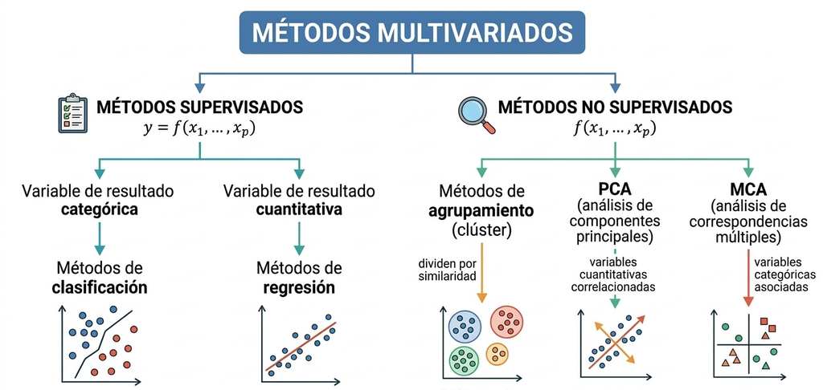

## Tipos de análisis

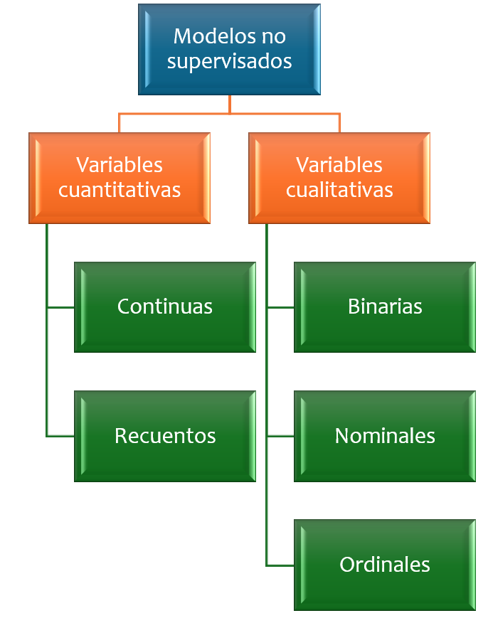

# ANÁLISIS DE COMPONENTES PRINCIPALES

## Objetivo general

Método para reducir la dimensionalidad de los datos conservando la mayor cantidad de información. El método se debe usar cuando las variables son cuantitativas y existe presencia de correlación

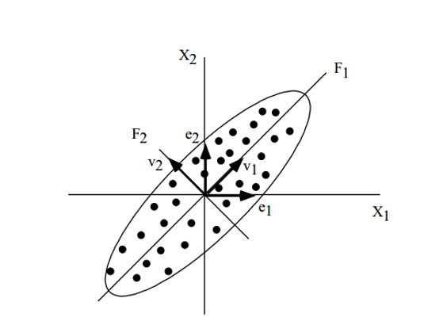

## Objetivos específicos

- **Visualizar patrones**: Sirve para visualizar la estructura de los datos y detectar patrones emergentes.
- **Construir de índices sintéticos**: Las variables originales se resumen en un conjunto menor de componentes principales que contienen información de todas las variables.
- **Identificar factores clave**: Identifica los factores principales que explican los cambios relacionados con el tema de interés.
- **Identificar grupos**: Ayuda a identificar grupos de individuos que comparten características similares.

## ¿Cómo funciona la técnica?

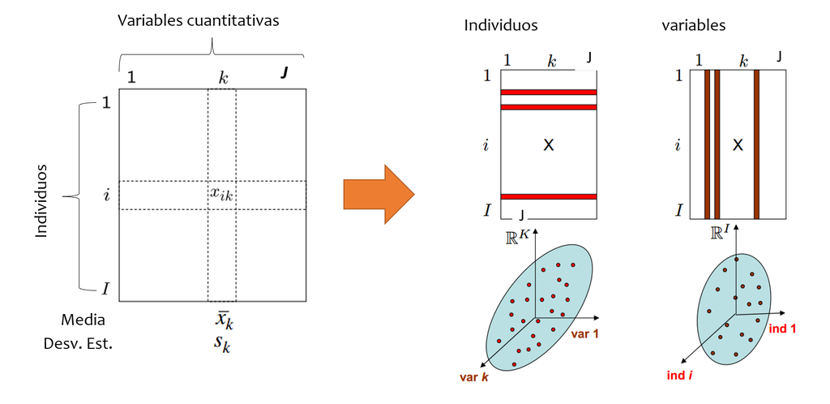

## Componentes principales

Reproducir la matriz original usando menos dimensiones

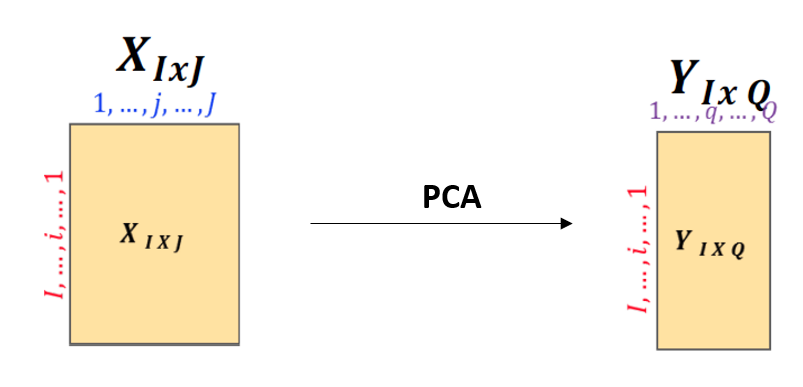

## Problema de optimización

Enfoque de Hotelling (1933) vs Pearson (1901)

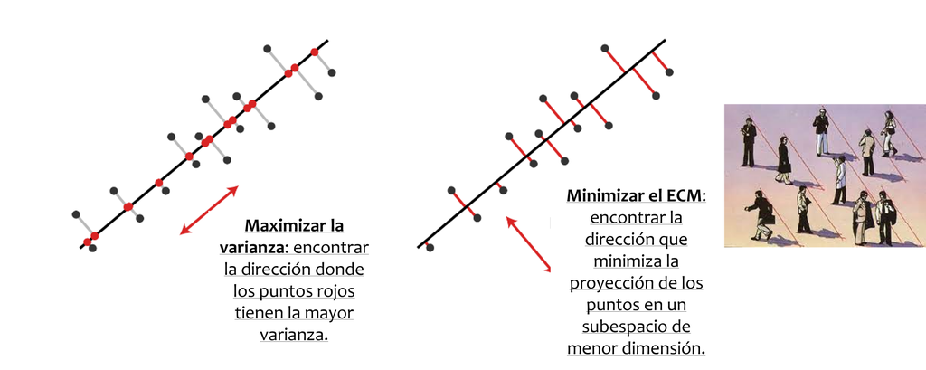

## Teorema de la factorización - SDV

Reproducir la matriz original con menos dimensiones.

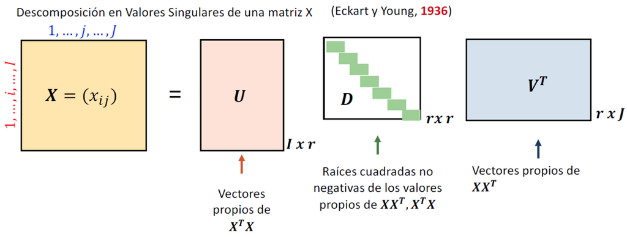

## Esquema de las componentes

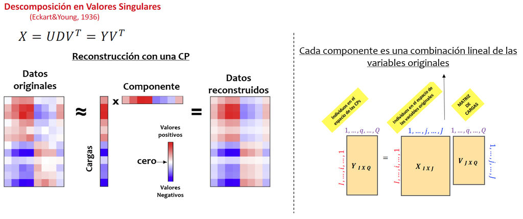

## Resumen

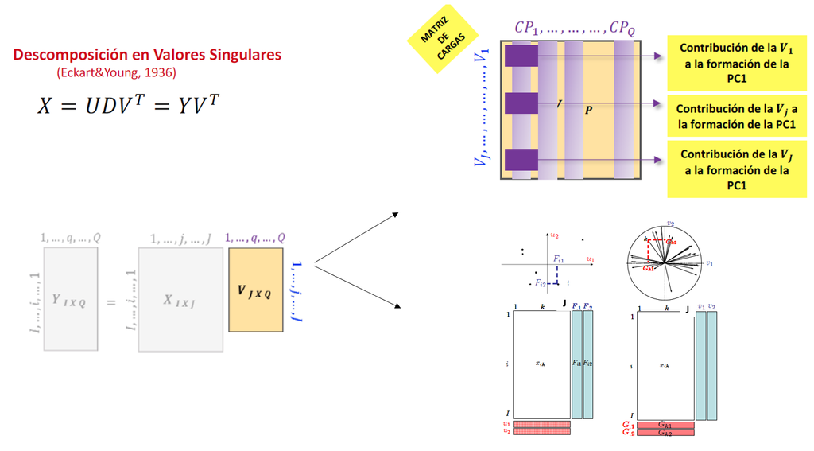

## Interpretación en el espacio de las componentes

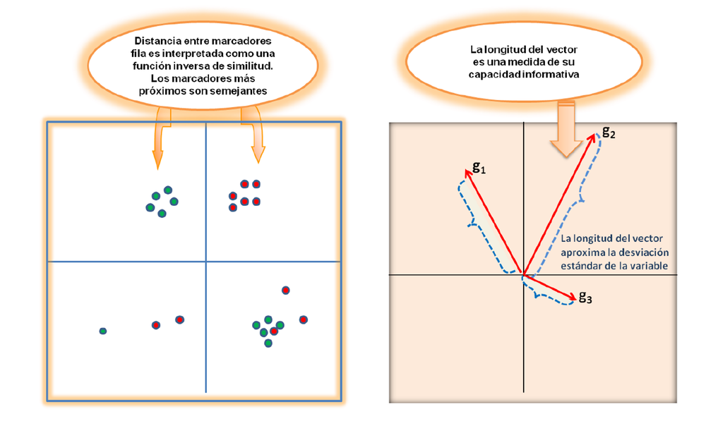

## Interpretación en el espacio de las componentes

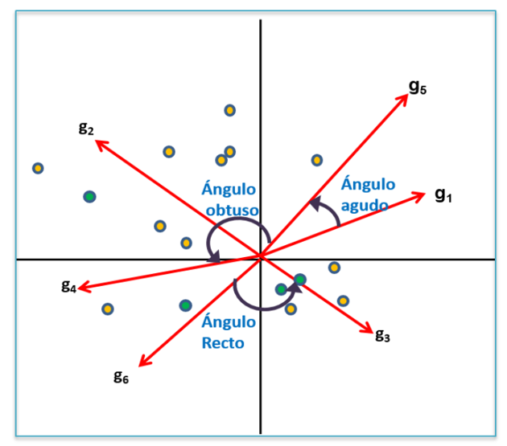

## Ejemplo

El conjunto de datos `RESUMEN.sav` contiene un preprocesamiento obtenido de la GEIH del DANE a nivel departamental para algunas variables de interés.

```r
library(pacman)
p_load(tidyverse, janitor,
       FactoMineR, factoextra, Factoshiny,
       skimr, corrplot, psych, gt, gtsummary, haven)

url <- "https://github.com/jgbabativam/AnaDatos/raw/main/datos/RESUMEN.sav"
datos <- read_sav(url) |> as_factor()
```

Use el comando `glimpse()` y `skim()` para explorar el conjunto de datos.

## Preparación del conjunto de datos

```r
datos <- datos |>
         column_to_rownames(var = "DPTO")
```

Observe que el conjunto de los datos está conformado únicamente por variables cuantitativas.

## Analice los resultados

```r
res <- PCA(datos, scale.unit = T, graph = F)
fviz_screeplot(res, addlabels = TRUE, ylim = c(0, 60))
```

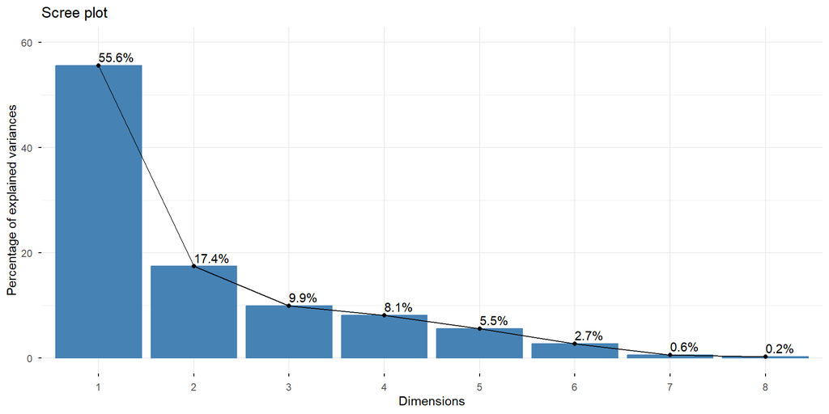

## Primer plano factorial para las variables

```r
fviz_pca_var(res,
             col.var="contrib",
             gradient.cols = c("#00AFBB", "#E7B800", "#FC4E07"),
             repel = TRUE)
```

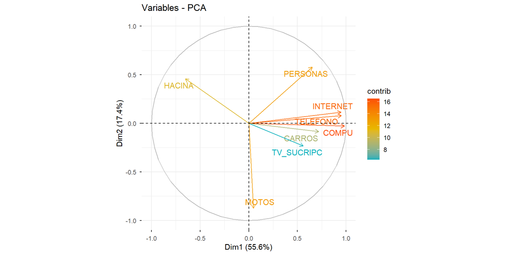

## Primer plano factorial para los individuos

```r
fviz_pca_ind(res, col.ind = "cos2",
             gradient.cols = c("#00AFBB", "#E7B800", "#FC4E07"),
             repel = TRUE)
```

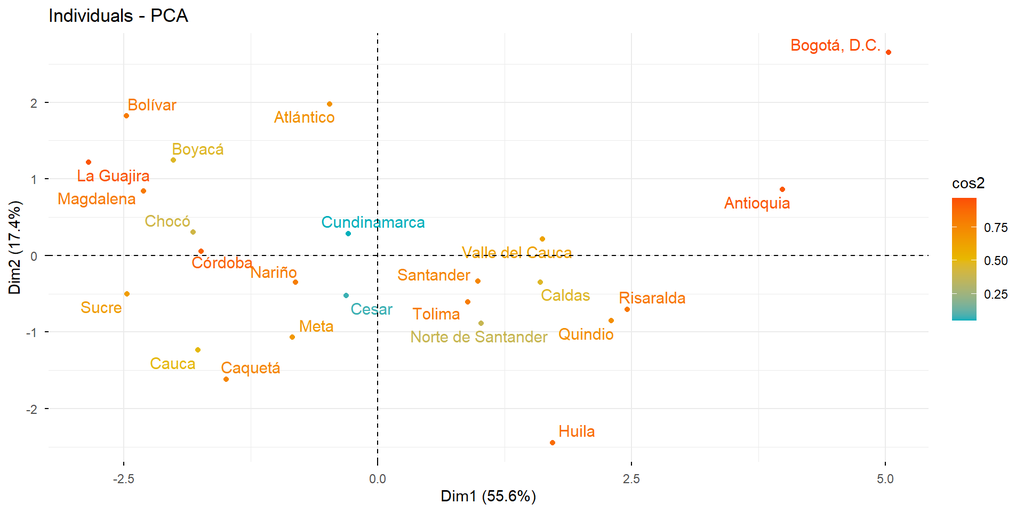

## Biplot

```r
fviz_pca_biplot(res, repel = TRUE, col.ind = "blue", col.var = "red")
```

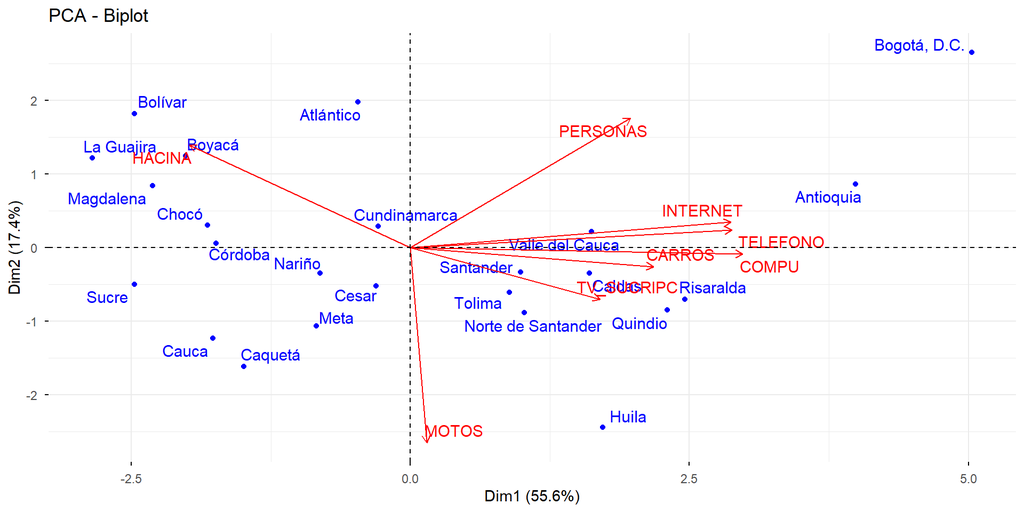

## Construcción de índices sintéticos

Tenga en cuenta que:

$$\mathbf{Y} = \mathbf{XV}$$

De manera que la matriz $\mathbf{V}$ son los ponderadores de las variables en la matriz $\mathbf{X}$, con lo cual $\mathbf{Y}$ es un índice que resume la información contenida en las variables originales.

## Complementos

- Explore el peso de las variables mediante la función `PCA(datos)` del paquete `FactoMineR`.
- Construya un índice a partir de la primera componente principal
- Use la función `Factoshiny(datos)` y ajuste los parámetros del modelo.

# ANÁLISIS DE CORRESPONDENCIAS

## Análisis de correspondencias

El *PCA* se usa para tratar variables cuantitativas que tienen algún grado de asociación lineal. De otra parte, el *análisis de correspondencias* es un método que surge de las tablas de contingencia y permite estudiar las relaciones entre variables cualitativas. Este análisis permite:

- Identificar patrones de asociación entre variables categóricas.
- Hacer una reducción de la dimensionalidad.
- Observar la proximidad entre individuos y entre variables.
- Hacer un pre-procesamiento para el análisis de clúster.

## Estructura del conjunto de datos

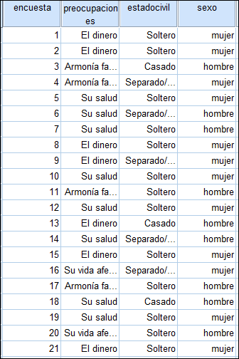

## Funcionamiento del análisis de correspondencias

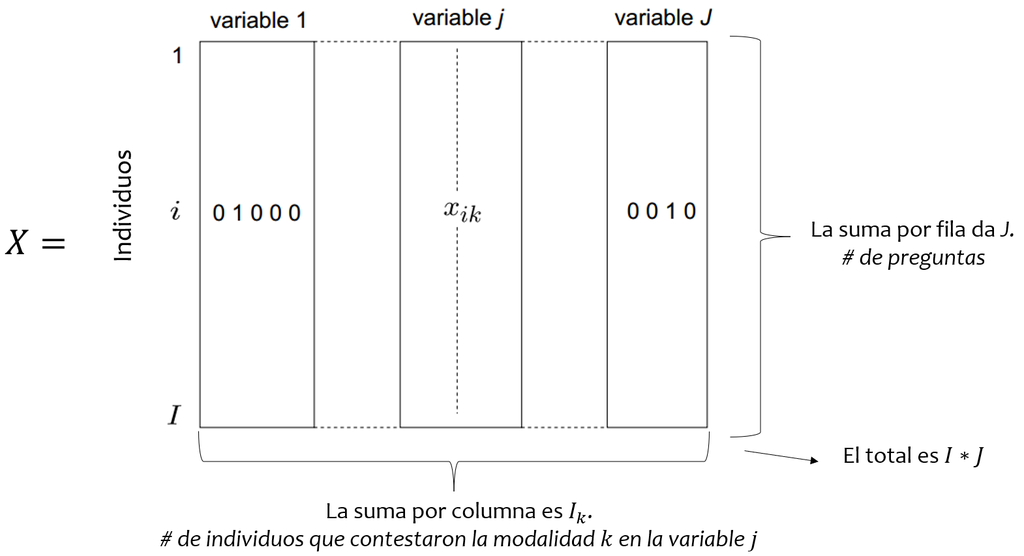

## Ejemplo: Matriz disyuntiva completa

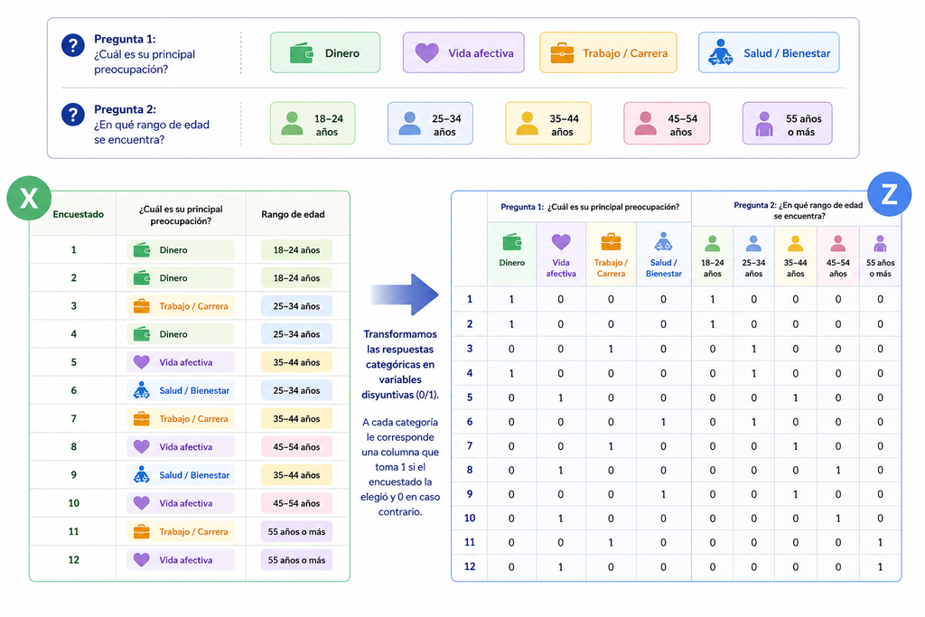

## Generación de tablas de contingencia

Al realizar la operación $\mathbf{X}^T\mathbf{X}$ se llega a la matriz que concatena todas las tablas de contingencia entre pares de variables, denominada matriz de *Burt*

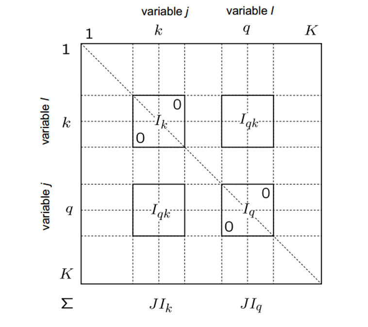

## Ejemplo: Tabla de Burt

[figure not shown]

## Proyección sobre el espacio factorial

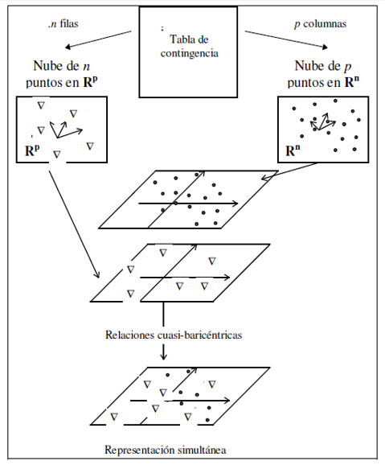

## Reglas de interpretación de las coordenadas

Guías para la interpretación con $Q=2$ preguntas.

- **Puntos fila, columna o mixtos cercanos entre sí** → los encuestados que contestaron una modalidad también contestaron la otra; sus distribuciones son similares.
- **Puntos cercanos al centro del plano** → modalidades con frecuencias **altas** de respuesta; representan la opinión de la mayoría (punto promedio o modal).
- **Puntos lejanos del origen** → modalidades con frecuencias **bajas** de respuesta; son las que más distinguen a los individuos.
- **Puntos en extremos opuestos del plano** → baja frecuencia de respuesta **y** distribuciones opuestas; indican opiniones contrapuestas.

**Warning**

El ACS **aleja del origen** las modalidades poco frecuentes, identificando así las características que más distinguen a los objetos.

## Guías para la interpretación

Todas las reglas del ACS ($Q=2$) son aplicables directamente al ACM ($Q>2$). Adicionalmente:

- **Proximidad entre individuos** → respondieron aproximadamente las mismas opciones de respuesta; tienen opiniones similares.
- **Proximidad entre modalidades de preguntas diferentes** → asociación entre ellas: fueron contestadas aproximadamente por los mismos individuos.
- **Proximidad entre modalidades de la misma pregunta** → las distribuciones de quienes las contestaron son similares (aunque sean excluyentes).
- **Modalidades suplementarias (cualitativas):** no participan en el cálculo pero se proyectan en el plano. Sus posiciones indican tendencias o perfiles.
- **Variables suplementarias cuantitativas:** se correlacionan con los factores usando la correlación variable–factor ($\sqrt{\lambda_\alpha}\, v_{j\alpha}$), igual que en ACP.

## Ejemplo

El conjunto de datos `corresp.sav` contiene 50 respuestas de una encuesta.

```r
library(pacman)
p_load(tidyverse, janitor, patchwork,
       FactoMineR, factoextra, Factoshiny,
       skimr, corrplot, psych, gt, gtsummary, haven)

url <- "https://github.com/jgbabativam/AnaDatos/raw/main/datos/corresp.sav"
datos <- read_sav(url) |> as_factor()
```

Use `glimpse()` y `skim()` para explorar el conjunto de datos.

## Preparación de los datos

```r
datos <- datos |>
         column_to_rownames(var = "encuesta")
```

- Analice la asociación entre las variables cualitativas.
- Explore la contribución y el coseno al cuadrado usando `MCA(datos)` del paquete `FactoMineR`.

## Analice los resultados

```r
res <- MCA(datos, graph = F)
fviz_screeplot(res, addlabels = TRUE, ylim = c(0, 40))
```

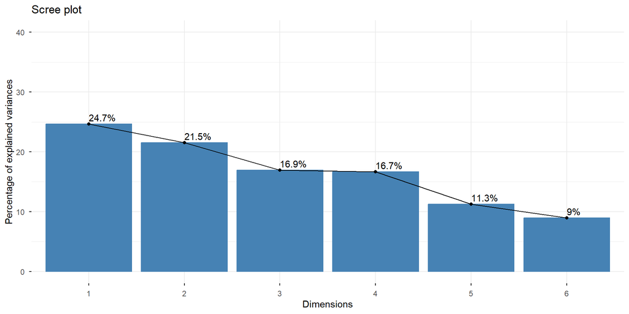

## Análisis de las contribuciones

```r
corrplot(res$var$contrib, is.corr=FALSE, tl.col = "black")
```

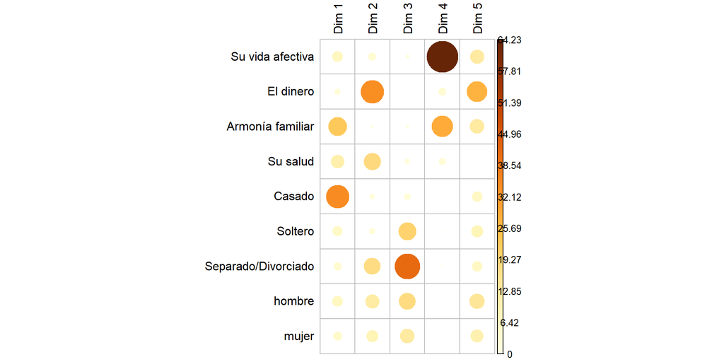

## Análisis de los cosenos

```r
corrplot(res$var$cos2, is.corr=FALSE, tl.col = "black")
```

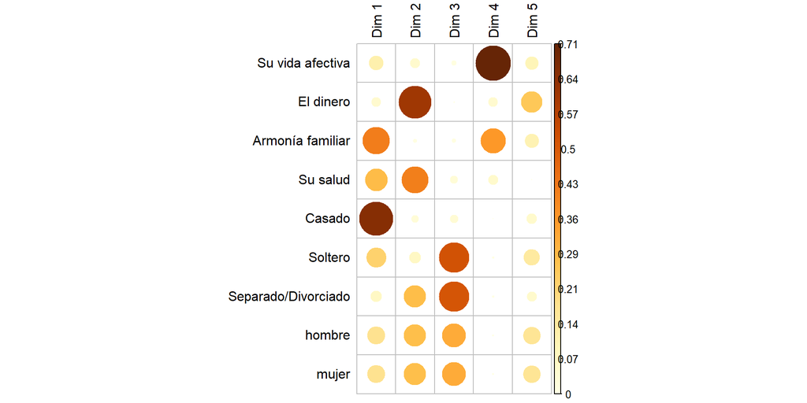

## Primer plano factorial

```r
fviz_mca_var(res, repel = TRUE, col.var = "blue")
```

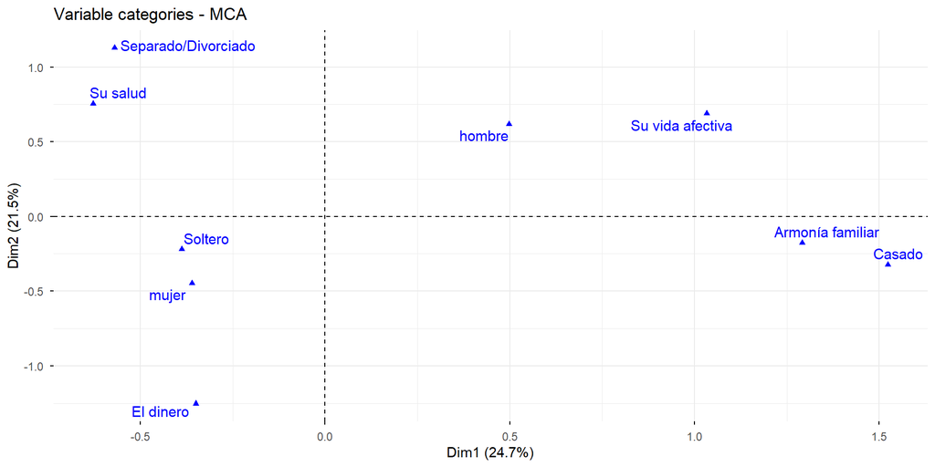

# ESTUDIOS DE CASO: ACS

# CASO 1: Confianza en la justicia en 38 países

## Encuesta Mundial de Valores

La **Encuesta Mundial de Valores** se realiza periódicamente desde 1981 e indaga opiniones sobre democracia, tolerancia, religión, medio ambiente y diversidad, entre otros temas.

Una de sus preguntas interroga por el **grado de confianza en la justicia** en 38 países, incluyendo varios latinoamericanos. La variable-fila es el **país** y la variable-columna es el **nivel de confianza** declarado por los encuestados.

```r
library(pacman)
p_load(tidyverse, janitor, FactoMineR, factoextra, corrplot)

url <- "https://github.com/jgbabativam/AnaDatos/raw/main/datos/"
conf_just <- read.csv2(paste0(url, "ConfianzaJUsticia.csv")) |>
             column_to_rownames("Pais") |>
             arrange(desc(muchis.))
```

## Tabla de contingencia: Países × Niveles de confianza

Grados de confianza en la justicia (Encuesta Mundial de Valores)

| País | muchis. | mucho | no_mucho | nada | no_sabe | no_resp. |
| --- | --- | --- | --- | --- | --- | --- |
| Dinamarca | 861 | 2 | 536 | 85 | 41 | 5 |
| Alemania | 549 | 2 | 952 | 195 | 119 | 15 |
| Canada | 375 | 2 | 1 | 324 | 0 | 0 |
| Austria | 332 | 860 | 361 | 77 | 17 | 4 |
| Rumania | 323 | 833 | 928 | 598 | 168 | 23 |
| Suiza | 317 | 2 | 787 | 126 | 44 | 19 |
| R Unido | 317 | 819 | 521 | 104 | 31 | 1 |
| Noruega | 299 | 666 | 131 | 15 | 13 | 0 |
| E Unidos | 289 | 1 | 909 | 173 | 3 | 27 |
| Australia | 254 | 814 | 569 | 155 | 0 | 21 |
| Finlandia | 241 | 721 | 201 | 34 | 19 | 3 |
| Suecia | 219 | 692 | 218 | 39 | 29 | 1 |
| Nueva Zelanda | 213 | 504 | 247 | 39 | 20 | 0 |
| Brasil | 208 | 678 | 404 | 408 | 60 | 4 |
| Paises Bajos | 205 | 1 | 802 | 151 | 135 | 5 |
| Francia | 189 | 907 | 525 | 211 | 47 | 1 |
| Hungria | 156 | 578 | 509 | 234 | 31 | 11 |
| Islandia | 155 | 826 | 535 | 86 | 26 | 5 |
| Espana | 155 | 414 | 447 | 180 | 8 | 5 |
| Estonia | 142 | 606 | 358 | 71 | 112 | 15 |
| Grecia | 130 | 580 | 353 | 119 | 11 | 7 |
| Italia | 125 | 785 | 944 | 372 | 42 | 14 |
| Serbia | 123 | 613 | 1 | 622 | 95 | 30 |
| Chequia | 117 | 563 | 736 | 303 | 86 | 24 |
| Mexico | 105 | 280 | 552 | 778 | 23 | 1 |
| Chipre | 101 | 391 | 347 | 113 | 40 | 7 |
| Colombia | 96 | 105 | 885 | 434 | 0 | 0 |
| Ecuador | 90 | 394 | 460 | 237 | 19 | 0 |
| Lituania | 79 | 616 | 537 | 101 | 112 | 8 |
| Portugal | 78 | 515 | 386 | 187 | 32 | 3 |
| Eslovaquia | 72 | 415 | 615 | 302 | 12 | 20 |
| Polonia | 62 | 413 | 532 | 249 | 94 | 8 |
| Eslovenia | 50 | 187 | 547 | 268 | 22 | 6 |
| Chile | 43 | 258 | 443 | 235 | 19 | 2 |
| Bulgaria | 40 | 187 | 717 | 550 | 54 | 18 |
| Croacia | 36 | 168 | 618 | 623 | 36 | 12 |
| Peru | 25 | 110 | 389 | 861 | 10 | 6 |
| Argentina | 17 | 176 | 427 | 365 | 16 | 1 |

## ACS: Confianza en la justicia

```r
acs_conf <- CA(conf_just, graph = FALSE)
#round(get_eigenvalue(acs_conf), 3)
```

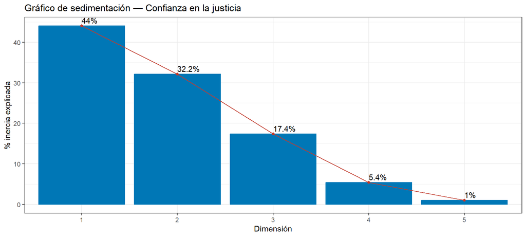

```r
fviz_eig(acs_conf, addlabels = TRUE, barfill = "#0077b6", barcolor = "#0077b6", linecolor = "#C0392B") +
  labs(title = "Gráfico de sedimentación — Confianza en la justicia", x = "Dimensión", y = "% inercia explicada") + theme_bw()
```

## Plano de columnas: niveles de confianza

```r
fviz_ca_col(acs_conf, repel = TRUE,
            col.col = "contrib",
            gradient.cols = c("#00AFBB", "#E7B800", "#FC4E07"),
            title = "Niveles de confianza — por contribución") + theme_bw()
```

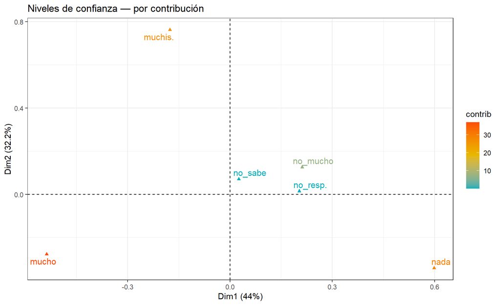

## Plano de filas: países

```r
fviz_ca_row(acs_conf, repel = TRUE, labelsize = 3,
            col.row = "cos2",
            gradient.cols = c("#00AFBB", "#E7B800", "#FC4E07"),
            title = "Países — grado de confianza en la justicia (cos²)") + theme_bw()
```

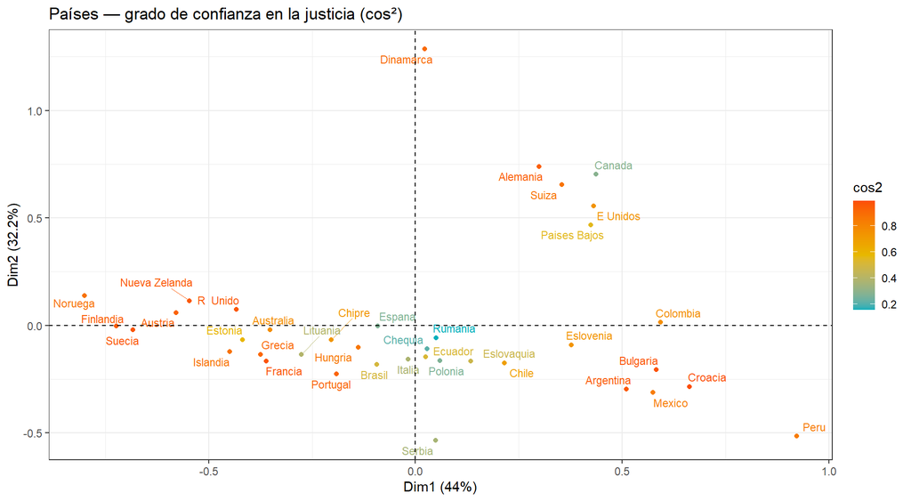

## Representación simultánea: países y niveles de confianza

```r
fviz_ca_biplot(acs_conf, repel = TRUE, labelsize = 3,
               col.row = "#0077b6", col.col = "#C0392B",
               title = "Asociación entre países y niveles de confianza en la justicia") +
  theme_bw()
```

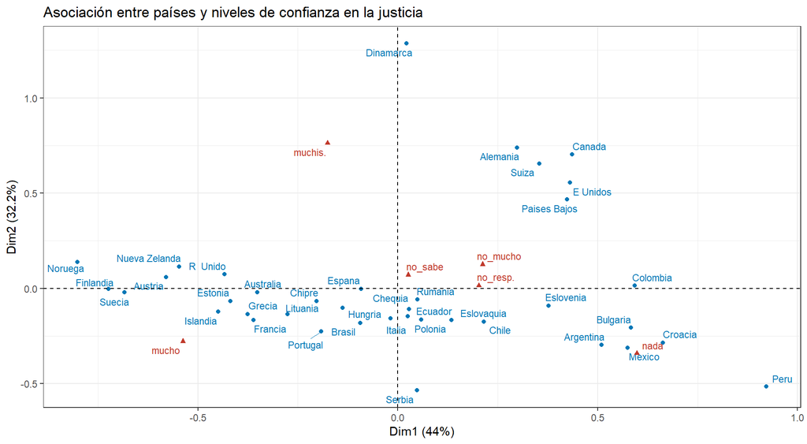

## Interpretación

# CASO 2: Elecciones Alcaldía de Bogotá 2023

## Contexto

En contextos electorales, identificar la percepción ciudadana hacia los candidatos resulta fundamental. Los datos analizados provienen de una muestra aleatoria de 300 personas, extraída de un estudio con 4894 encuestas aplicadas en todas las localidades de Bogotá. El instrumento evaluó a los candidatos a la Alcaldía de Bogotá 2023 mediante preguntas de selección múltiple, donde los participantes asignaron diversos atributos a cada perfil.

La tabla resultante es:

| Dimensión | Descripción |
| --- | --- |
| **Filas** | 26 atributos percibidos (positivos, negativos, ideológicos, de alineación política) |
| **Columnas** | 9 candidatos (incluye “Ninguno” y “Ns/Nr”) |

El ACS permite construir el **mapa perceptivo** de los candidatos.

## Diseño del cuestionario

Se entrega a los entrevistados una tarjeta con la imagen y nombres de los candidatos. Luego se leen los atributos y para cada uno el encuestado responde con cuál(es) candidatos lo asocia.

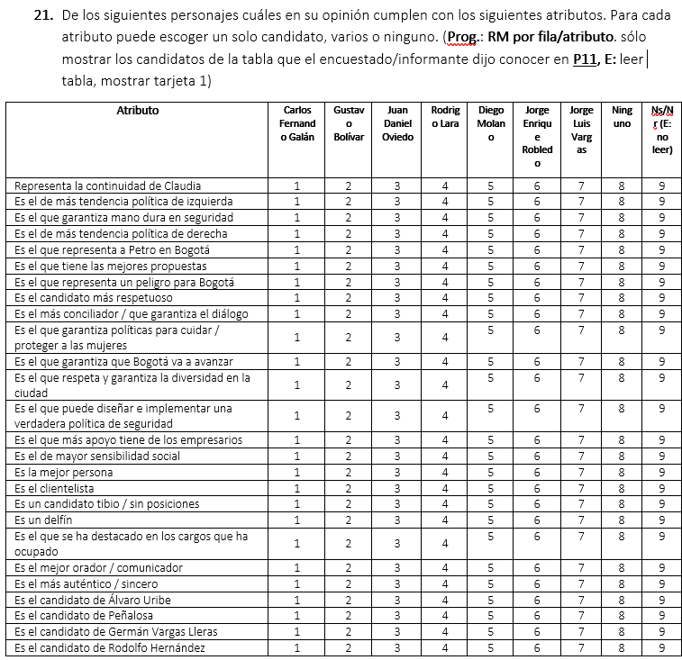

## Cargue de los datos

El ambiente político en el momento electoral es decisivo, identificar patrones y asociaciones en las opiniones resulta clave en las estrategias que se deben seguir durante la campaña. Considere el siguiente conjunto de datos obtenido de una muestra aleatoria de 300 personas y construya el perfil de los candidatos a partir de un análisis de correspondencias.

```r
library(pacman)
p_load(tidyverse, janitor,
       FactoMineR, factoextra, Factoshiny,
       skimr, corrplot, psych, gt, gtsummary, haven)

url <- "https://github.com/jgbabativam/AnaDatos/raw/main/datos/df_clase.sav"
clase <- read_sav(url)
```

Explore el conjunto de datos con `glimpse(as_factor(clase))` y compare con el cuestionario

## Ordenar y transformar

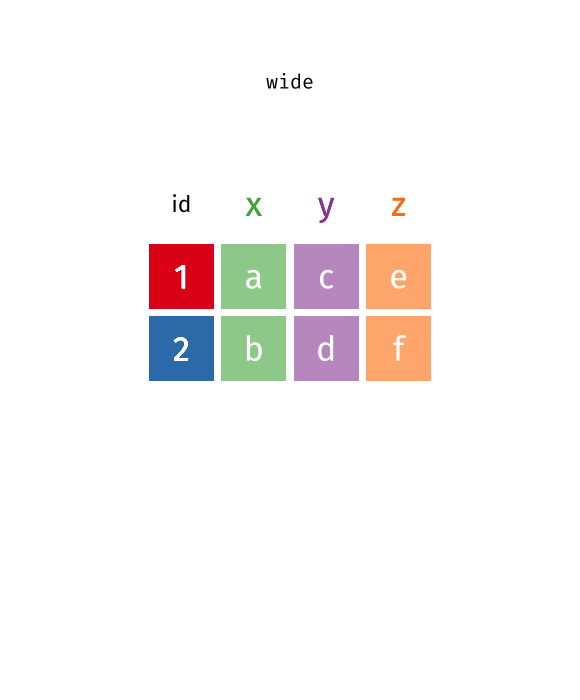

[Fuente: tidyexplain](https://www.garrickadenbuie.com/project/tidyexplain/)

## Ordenar y transformar

Una forma de trabajar el conjunto de los datos es transformarlo a un formato largo:

```r
df <- clase |>
      pivot_longer(cols = starts_with("P21"), names_to = "P21", values_to = "respuesta")
```

Observe que hay respuestas múltiples en algunos atributos.

```r
head(df |> filter(as.numeric(respuesta)>10))
```

```
# A tibble: 6 × 6
     id GENERO        REDAD        RESTRATO  P21    respuesta
  <dbl> <dbl+lbl>     <dbl+lbl>    <dbl+lbl> <chr>  <dbl+lbl>
1     1 1 [Masculino] 3 [35 - 44]  2 [Medio] P21_20      46
2     2 1 [Masculino] 1 [18 a 24]  2 [Medio] P21_7       57
3     2 1 [Masculino] 1 [18 a 24]  2 [Medio] P21_20      26
4     4 1 [Masculino] 5 [55 o más] 2 [Medio] P21_13 1234567
5     4 1 [Masculino] 5 [55 o más] 2 [Medio] P21_17      14
6     4 1 [Masculino] 5 [55 o más] 2 [Medio] P21_19      14
```

## Ordenar y transformar

Separamos las respuestas en diferentes variables para poder tratarlas

```r
longitud_maxima <- max(nchar(df$respuesta))
nombres_columnas <- paste0("respuesta_", 0:longitud_maxima)

df1 <- df |>
       separate(respuesta, into = nombres_columnas, sep = "", fill = "right") |>
       select(-respuesta_0)
```

Volvemos a reestructurar los datos para que cada persona quede solo con las respuestas que asignó en cada atributo

```r
df_reest <- df1 |>
            pivot_longer(cols = starts_with("respuesta_"),
                         names_to = "var", values_to = "candidato", values_drop_na = TRUE) |>
            select(-var)
```

## Asignación de atributos

```r
df_reest <- df_reest |>
             separate(P21, c("pregunta", "item"), sep = "_") |>
             mutate(item = factor(item, levels = 1:26,
                                  labels = c(
                                    'Representa la continuidad de Claudia',
                                    'Tendencia política de izquierda',
                                    'Garantiza mano dura en seguridad',
                                    'Tendencia política de derecha',
                                    'Representa a Petro en Bogotá',
                                    'Tiene las mejores propuestas',
                                    'Representa un peligro para Bogotá',
                                    'Es el candidato más respetuoso',
                                    'Es el más conciliador',
                                    'Garantiza políticas para proteger a las mujeres',
                                    'Garantiza que Bogotá va a avanzar',
                                    'Respeta y garantiza la diversidad en la ciudad',
                                    'Puede diseñar e implementar una verdadera política de seguridad',
                                    'Es el que más apoyo tiene de los empresarios',
                                    'Es el de mayor sensibilidad social',
                                    'Mejor persona',
                                    'Clientelista',
                                    'Tibio/sin posiciones',
                                    'Delfín',
                                    'Se ha destacado en los cargos que ha ocupado',
                                    'Mejor comunicador',
                                    'Más auténtico',
                                    'Es el candidato de Álvaro Uribe',
                                    'Es el candidato de Peñalosa',
                                    'Es el candidato de Germán Vargas Lleras',
                                    'Es el candidato de Rodolfo Hernández'
                                  ))) |>
             mutate(candidato = factor(as.numeric(candidato), levels = 1:9,
                                     labels = c('Carlos Fernando Galán',
                                                'Gustavo Bolívar',
                                                'Juan Daniel Oviedo',
                                                'Rodrigo Lara',
                                                'Diego Molano',
                                                'Jorge Enrique Robledo',
                                                'Jorge Luis Vargas',
                                                'Ninguno',
                                                'Ns/Nr'))) |>
             mutate(GENERO = factor(GENERO, levels = 1:2, labels = c("Hombre", "Mujer")),
                    REDAD = factor(REDAD, levels = 1:5, labels = c("18 a 24",
                                                                   "25 a 34",
                                                                   "35 a 44",
                                                                   "45 a 54",
                                                                   "55 o más"))) |>
              select(-pregunta)
```

## Preparación de los datos

Con la estructura de los datos se puede construir la tabla de contingencia para aplicar un análisis de correspondencias simple

```r
tabla <- df_reest |>
         count(item, candidato) |>
         pivot_wider(names_from = candidato, values_from = n) |>
         column_to_rownames("item")
```